# W271 Section 3 Lab 4

# IV. Identifying the Dependence Orders for Estimated Models

In the plots of the differenced data, there are spikes in the PACF at lags 12, 24, 36 .. and a spike in ACF at lag 12, suggesting a seasonal MA(1) component.

There are significant spikes at lags 2, 5 in both the ACF and PACF, suggesting a possible MA(2) or AR(2) term, however, the choice is not obvious.

We decided to start with an ARIMA(0,1,2)(0,1,1)[12] and manually fit some variations on it to identify the models with the lowest AIC and AICc values. In addition, we also consider the out-of-sample performance (MAPE) on the testing data.

## Defining a Function for Optimizing the Dependence Orders

Since the procedure was repetitive, we defined a function for model testing:

```r
# Define a function for testing models
model.test <- function(ORDER, SEASONAL) {

  fit.test <- Arima(ms.training, order=ORDER, seasonal = SEASONAL)
  fit.test$residuals %>% ggtsdisplay     # residual plot

  # find MAPE
  f1 <- ms.training %>% Arima(order = ORDER, seasonal=list(order=SEASONAL,period=12)) %>% forecast(h = 11)

  # return AIC, AICc, BIC, MAPE.train, MAPE.test
  temp <- cbind(fit.test[6], fit.test[15], fit.test[16], accuracy(f1,ms.test)[1,5], accuracy(f1,ms.test)[2,5])
  colnames(temp) = c("AIC", "AICc", "BIC", "MAPE.train", "MAPE.test")
  rownames(temp) = NULL
  temp
}
```

## Model Testing

```r
# Define the model to be tested
Order = c(2,1,2)       # order
Seasonal = c(0,1,1)    # seasonal component

model.test(Order, Seasonal)
```

[output not shown]

## Summary of Models

Candidate Models

ARIMA AIC AICc BIC MAPE.train MAPE.test

(0,1,5)(0,1,1)[12] -120.65 -120.25 -95.03 2.36 5.88

(0,1,6)(0,1,1)[12] -120.24 -119.72 -90.96 2.35 5.66

(1,1,1)(0,1,1)[12] -122.71 -122.57 -108.08 2.39 3.32

(1,1,2)(0,1,1)[12] -125.81 -125.60 -107.52 2.36 3.85

(1,1,3)(0,1,1)[12] -123.83 -123.53 -101.87 2.36 3.81

(1,1,1)(0,1,2)[12] -122.23 -122.01 -103.93 2.38 3.67

(2,1,1)(0,1,1)[12] -125.86 -125.64 -107.56 2.36 3.77

(3,1,1)(0,1,1)[12] -123.86 -123.56 -101.9 2.36 3.78

(2,1,1)(1,1,1)[12] -125.55 -125.25 -103.59 2.35 4.11

(1,1,1)(1,1,1)[12] -122.40 -122.19 -104.10 2.38 3.69

(2,1,1)(0,1,2)[12] -125.38 -125.08 -103.42 2.35 4.11

(2,1,2)(0,1,1)[12] -123.86 -123.56 -101.90 2.36 3.79

## Grid Search to Optimize Model Dependence Orders

To expand the search space and identify any models that might surpass those we already estimated, we conducted a grid search.

```r
results <- data.frame(p = 1:25, q = 1:25, AIC = 0, AICc = 0, BIC = 0)
for (p in 1:5){
  for (q in 1:5){
    m <- ms.training %>% Arima(order = c(p, 1, q), seasonal=list(order=c(0,1,1),period=12))
    index <- (p-1)*5 + q
    results[index,] = c(p,q,m$aic, m$aicc, m$bic)
  }
}
rbind(results[which.min(results$AIC),], results[which.min(results$AICc),], results[which.min(results$BIC),])
```

[output not shown]

## Candidate Models

We found that the grid search corraborated our exploratory analysis.

We have looked for an optimal p,q combination within the $p \in {1,5}$ and $q \in {1,5}$.

Based on the information criteria optimization, we decided to focus on the following models:

- ARIMA(1,1,1)(0,1,1)[12] because it minimized the BIC.
- ARIMA(2,1,1)(0,1,1)[12] because it minimized the AIC and AICc.

# Model Parameter Estimation

```r
fit111 <- ms.training %>% Arima(order = c(1, 1, 1), seasonal=list(order=c(0,1,1),period=12))
summary(fit111)
```

```
Series: .
ARIMA(1,1,1)(0,1,1)[12]

Coefficients:
         ar1      ma1     sma1
      0.9311  -0.8047  -0.8909
s.e.  0.0388   0.0560   0.0520

sigma^2 estimated as 0.03519:  log likelihood=65.36
AIC=-122.71   AICc=-122.57   BIC=-108.08

Training set error measures:
                       ME      RMSE       MAE        MPE     MAPE      MASE       ACF1
Training set -0.009339336 0.1825311 0.1427566 -0.1059365 2.389875 0.1763078 -0.1050292
```

```r
fit211 <- ms.training %>% Arima(order = c(2, 1, 1), seasonal=list(order=c(0,1,1),period=12))
summary(fit211)
```

```
Series: .
ARIMA(2,1,1)(0,1,1)[12]

Coefficients:
         ar1     ar2      ma1     sma1
      0.7289  0.1592  -0.7036  -0.8825
s.e.  0.1030  0.0680   0.0900   0.0512

sigma^2 estimated as 0.03476:  log likelihood=67.93
AIC=-125.86   AICc=-125.64   BIC=-107.56

Training set error measures:
                       ME      RMSE       MAE        MPE     MAPE      MASE         ACF1
Training set -0.008926836 0.1810804 0.1416233 -0.1017597 2.364688 0.1749081 -0.004085812
```

The model parameters we estimated for both our candidates are all statistically significant (criterion = 2*SE<Parameter).

# VI. Model Validation with Model Diagnostics

We performed and examined the model diagnostics for the two models we favored.

## ARIMA(1,1,1)(0,1,1)[12]

```
    Ljung-Box test

data:  Residuals from ARIMA(1,1,1)(0,1,1)[12]
Q* = 24.11, df = 21, p-value = 0.2878

Model df: 3.   Total lags used: 24
```

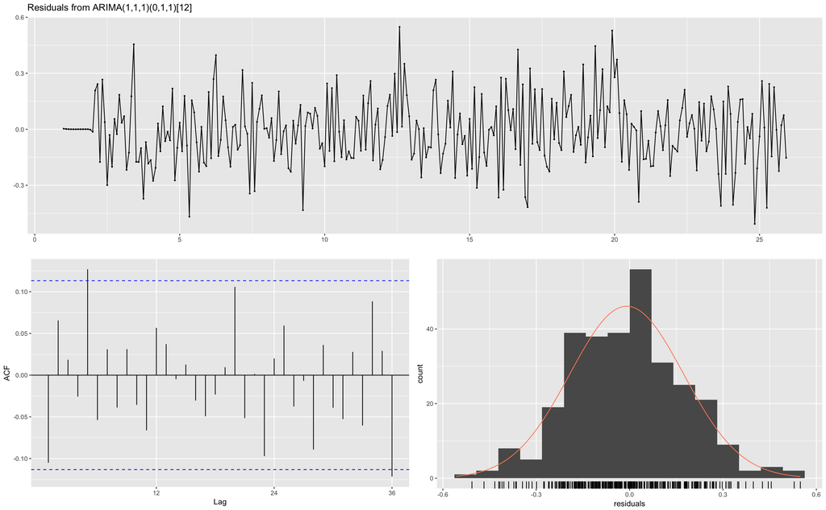

```r
res111 <- residuals(fit111)
#ggtsdisplay(res111)
checkresiduals(fit111)
```

## ARIMA(2,1,1)(0,1,1)[12]

```
    Ljung-Box test

data:  Residuals from ARIMA(2,1,1)(0,1,1)[12]
Q* = 19.069, df = 20, p-value = 0.5174

Model df: 4.   Total lags used: 24
```

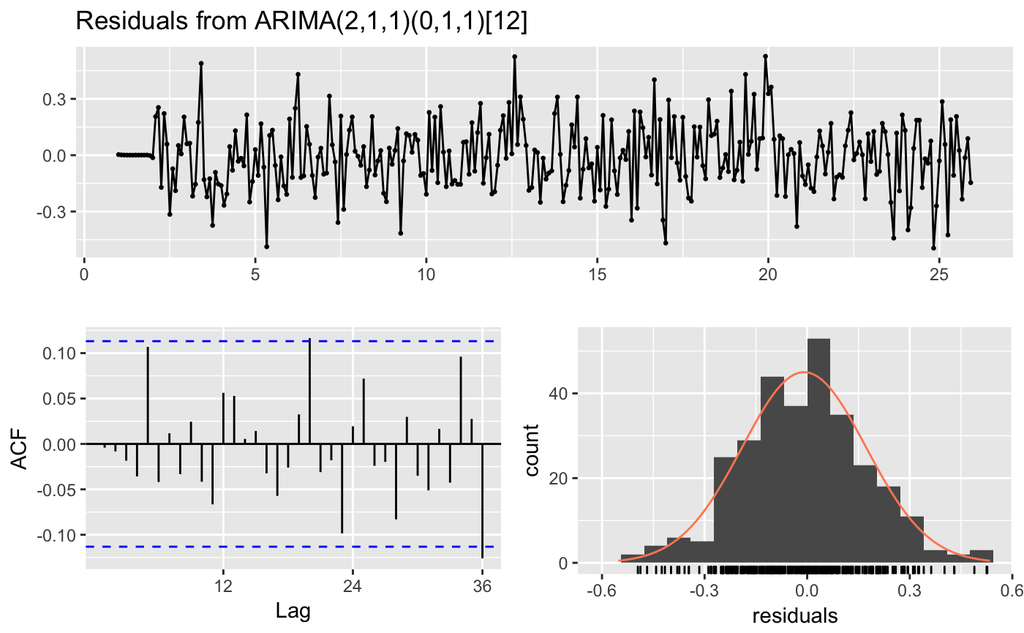

```r
res211 <- residuals(fit211)
#ggtsdisplay(res211)
checkresiduals(fit211)
```

These diagnostic tests provide support for accepting the model assumptions required for valid time series modeling and forecasting. We can therefore proceed to forecasting with confidence.